# act_report

## Insights and Visualizations

> After completing the entire wrangling process, we move on to analysis and visualization.

> I have put before myself 3 questions that interest me:
- *What are the most common names?*
- *Which breed gets the highest rating on average?*
- *What is the most common stage of the dog in a DataFrame?*

> To answer these questions I had to pull the data I needed from the recently cleared data. I decided to use the SQLite program. First, I converted the cleaned data to a CSV file and downloaded it to my PC. Then I loaded this file into the program and, using SQL queries, I received the DataFrames I needed. I transferred these data frames back to a csv file and download to Jupyter Notebook. Using this data and matplotlib I created visualizations to answer my questions.

*What are the most common names?*

[figure not shown]

*Which breed gets the highest rating on average?*

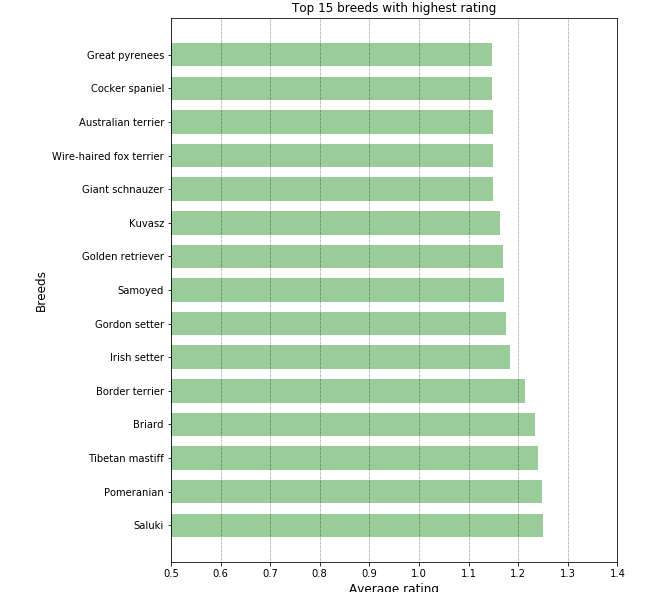

As we can see from the visualization, the top rated breeds are Saluki and Pomeranian (~1.25).

*What is the most common stage of the dog in a DataFrame?*

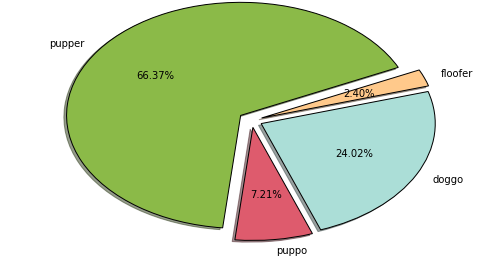

As we can see from the pie chart, the most(more than a half) common stage of a dog is pupper(66.37%). Then follows doggo and puppo with 24.02% and 7.21% respectively. The smallest share belongs to floofer(2.40%)